# OverView

The United States Census Bureau (USCB), officially the Bureau of the Census, is a principal agency of the U.S. Federal Statistical System, responsible for producing data about the American people and economy. The Census Bureau's primary mission is conducting the U.S. Census every ten years, which allocates the seats of the U.S. House of Representatives to the states based on their population. The Bureau's various censuses and surveys help allocate over $675 billion in federal funds every year and it helps states, local communities, and businesses make informed decisions. The information provided by the census informs decisions on where to build and maintain schools, hospitals, transportation infrastructure, and police and fire departments.

# why this is analysis important ?

- Census statistics can help businesses to understand customers and answer important decisions including, depending on the type of commercial activity.
- Where are the best places for new retail outlets?
- What products and services should be offered in stores?
- Where is the best place to advertise?
- Which areas and people should be surveyed?
- Major business decisions invariably carry an element of risk, so anything that increases confidence and minimises risk is to be welcomed.
- Census statistics can inform growth plans and provide management, board and investors with reliable evidence and the confidence to enable them to make those important decisions.
- The data can also help to identify where your business might benefit from more detailed market research to address specific business development issues

# Problem Definition:

```
Given a Census with general information about randomly choosen US citizens, can we predict whether their annual income is above or below 50K?
```

## 1- Data

Data provided in CSV file format with approximtly 33000 Observations

## 2- Data Cleaning

## 3- Exploratory Data Analysis & Build insights

## 4-Feature Encoding

## 5- Building Model

```
  in this part we tried many algorithms (KNN,Logistic Regression, Random Forest, XGboost, Catboost)
```

## 6- Tuning Hyperparameters

```
Choosing best_model and tune its hyperparameter to get more performed model
```

## 7-Evaluation

```
Will be the model able to reach a 90% Accuracy at predicting whether a US citizen has an yearly income higher or lower than 50K?
```

## 8-Important Features

```
In this part we try to get the features which affect the model prediction and Training
```

## Data Features

- age:

  ```
  continuous value
  ```

- workclass:

  ```
  Private Self-emp-not-inc, Self-emp-inc, Federal-gov, Local-gov, State-gov, Without-pay, Never-worked.
  ```

- education:

  ```
  Bachelors, Some-college, 11th, HS-grad, Prof-school, Assoc-acdm, Assoc-voc, 9th, 7th-8th, 12th, Masters, 1st-4th, 10th, Doctorate, 5th-6th, Preschool.
  ```

- education_num:

  ```
  continuous value
  ```

- marital_status:

  ```
  Married-civ-spouse, Divorced, Never-married, Separated, Widowed, Married-spouse-absent, Married-AF-spouse.
  ```

- occupation:

  ```
  Tech-support, Craft-repair, Other-service, Sales, Exec-managerial, Prof-specialty, Handlers-cleaners, Machine-op-inspct, Adm-clerical, Farming-fishing, Transport-moving, Priv-house-serv, Protective-serv, Armed-Forces.
  ```

- relationship:

  ```
  Wife, Own-child, Husband, Not-in-family, Other-relative, Unmarried.
  ```

- race:

  ```
  White, Asian-Pac-Islander, Amer-Indian-Eskimo, Other, Black.
  ```

- sex:

  ```
  Female, Male.
  ```

- capital_gain:

  ```
  continuous value. profit one earns on the sale of an asset like stocks, bonds or real estate
  ```

- capital_loss:

  ```
  continuous value. loss one incurs on the sale of an asset like stocks, bonds or real estate.
  ```

- hours_per_week:

  ```
  continuous value.number of working hours per week
  ```

- native_country:

  ```
  United-States, Cambodia, England, Puerto-Rico, Canada, Germany, Outlying-US(Guam-USVI-etc), India, Japan, Greece, South China, Cuba, Iran, Honduras, Philippines, Italy, Poland, Jamaica, Vietnam, Mexico, Portugal, Ireland, France, Dominican-Republic, Laos, Ecuador, Taiwan, Haiti, Columbia, Hungary, Guatemala, Nicaragua, Scotland, Thailand, Yugoslavia, El-Salvador, Trinadad&Tobago, Peru, Hong, Holand-Netherlands.
  ```

- class:

  ```
  >50K or <=50K (annual income )
  ```

- income value

  ```
  Actual income
  ```

# Import Libraries

```python
import numpy as np
import pandas as pd
import seaborn as sns
import matplotlib.pyplot as plt
import math
from bubble_plot.bubble_plot import bubble_plot

%matplotlib inline
```

```python
! pip install bubble_plot
```

# Reading Data

```python
df=pd.read_csv("/content/drive/MyDrive/EFG/census_income_original_2.csv")
df = df.set_index('ID')
```

```python
df.head(10)
```

| ID | age | workclass | education | education.num | marital.status | occupation | relationship | race | Gender | capital.gain | capital.loss | hours.per.week | native.country | income | income_value |
| --- | --- | --- | --- | --- | --- | --- | --- | --- | --- | --- | --- | --- | --- | --- | --- |
| 1 | 90 | ? | HS-grad | 9 | Widowed | ? | Not-in-family | White | Female | 0 | 4356 | 40 | United-States | <=50K | 7986 |
| 2 | 82 | Private | HS-grad | 9 | Widowed | Exec-managerial | Not-in-family | White | Female | 0 | 4356 | 18 | United-States | <=50K | 4566 |
| 3 | 66 | ? | Some-college | 10 | Widowed | ? | Unmarried | Black | Female | 0 | 4356 | 40 | United-States | <=50K | 2571 |
| 4 | 54 | Private | 7th-8th | 4 | Divorced | Machine-op-inspct | Unmarried | White | Female | 0 | 3900 | 40 | United-States | <=50K | 8611 |
| 5 | 41 | Private | Some-college | 10 | Separated | Prof-,specialty | Own-child | White | Female | 0 | 3900 | 40 | United-States | <=50K | 1553 |
| 6 | 34 | Private | HS-grad | 9 | Divorced | Other-service | Unmarried | White | female | 0 | 3770 | 45 | United-States | <=50K | 7560 |
| 7 | 38 | Private | 10th | 6 | Separated | Adm-clerical | Unmarried | White | Male | 0 | 3770 | 40 | United-States | <=50K | 4204 |
| 8 | 74 | State-gov | Doctorate | 16 | Never-married | Prof-,specialty | Other-relative | White | female | 0 | 3683 | 20 | United-States | >50K | NaN |
| 9 | 68 | Federal-gov | HS-grad | 9 | Divorced | Prof-,specialty | Not-in-family | White | female | 0 | 3683 | 40 | United-States | <=50K | 481 |
| 10 | 41 | Private | Some-college | 10 | Never-married | Craft-repair | Unmarried | White | Male | 0 | 3004 | 60 | ? | >50K | NaN |

```python
df.sample(10)
```

| ID | age | workclass | education | education.num | marital.status | occupation | relationship | race | Gender | capital.gain | capital.loss | hours.per.week | native.country | income | income_value |
| --- | --- | --- | --- | --- | --- | --- | --- | --- | --- | --- | --- | --- | --- | --- | --- |
| 26395 | 32 | Self-emp-not-inc | Bachelors | 13 | Married-civ-spouse | Sales | Other-relative | White | Male | 0 | 0 | 45 | United-States | <=50K | NaN |
| 22203 | 56 | Self-emp-inc | Assoc-voc | 11 | Married-civ-spouse | Sales | Husband | White | Male | 0 | 0 | 54 | United-States | >50K | NaN |
| 347 | 50 | Private | HS-grad | 9 | Never-married | Adm-clerical | Not-in-family | White | Male | 0 | 1980 | 40 | United-States | <=50K | 7616.0 |
| 19183 | 57 | Self-emp-inc | Prof-school | 15 | Married-civ-spouse | Prof-specialty | Husband | Asian-Pac-Islander | Male | 0 | 0 | 50 | Taiwan | >50K | NaN |
| 27789 | 44 | Local-gov | Assoc-acdm | 12 | Married-civ-spouse | Farming-fishing | Husband | White | Male | 0 | 0 | 30 | United-States | <=50K | NaN |
| 15782 | 65 | Self-emp-not-inc | Some-college | 10 | Widowed | Exec-managerial | Unmarried | White | Female | 0 | 0 | 45 | United-States | <=50K | 1389 |
| 14717 | 49 | Private | 5th-6th | 3 | Never-married | Machine-op-inspct | Not-in-family | White | Male | 0 | 0 | 45 | United-States | <=50K | 3016 |
| 27964 | 17 | Private | 11th | 7 | Never-married | Other-service | Own-child | White | Male | 0 | 0 | 25 | United-States | <=50K | NaN |
| 20913 | 42 | Private | Bachelors | 13 | Never-married | Sales | Not-in-family | White | Male | 0 | 0 | 40 | United-States | <=50K | NaN |
| 14382 | 38 | Private | Assoc-voc | 11 | Never-married | Craft-repair | Not-in-family | White | Female | 0 | 0 | 40 | Portugal | <=50K | 5648 |

# Data issues

```python
df.info()
```

```
<class 'pandas.core.frame.DataFrame'>
Int64Index: 33333 entries, 1 to 776
Data columns (total 15 columns):
 #   Column          Non-Null Count  Dtype
---  ------          --------------  -----
 0   age             33333 non-null  int64
 1   workclass       33333 non-null  object
 2   education       33333 non-null  object
 3   education.num   33333 non-null  int64
 4   marital.status  33333 non-null  object
 5   occupation      33333 non-null  object
 6   relationship    33333 non-null  object
 7   race            33333 non-null  object
 8   Gender          33333 non-null  object
 9   capital.gain    33333 non-null  int64
 10  capital.loss    33333 non-null  int64
 11  hours.per.week  33333 non-null  int64
 12  native.country  33333 non-null  object
 13  income          33333 non-null  object
 14  income_value    13190 non-null  object
dtypes: int64(5), object(10)
memory usage: 4.1+ MB
```

```python
def CM(x):
    return sum(x=='?')
df.apply(CM)
```

```
age                  0
workclass         1860
education            0
education.num        0
marital.status       0
occupation        1867
relationship         0
race                 0
Gender               0
capital.gain         0
capital.loss         0
hours.per.week       0
native.country     603
income               0
income_value         0
dtype: int64
```

```python
def CM2(x):
    return sum(x=='NA')
df.apply(CM2)
```

```
age               0
workclass         0
education         0
education.num     0
marital.status    0
occupation        0
relationship      0
race              0
Gender            0
capital.gain      0
capital.loss      0
hours.per.week    0
native.country    0
income            0
income_value      0
dtype: int64
```

```python
df['income_value'].isnull().sum()
```

```
20143
```

```python
for i in df.columns:
    if type(df[i][1])== str:
        print(df[i].value_counts())
        print("**********************")
```

```
Private             23170
Self-emp-not-inc     2636
Local-gov            2150
?                    1860
State-gov            1327
Self-emp-inc         1180
Federal-gov           989
Without-pay            14
Never-worked            7
Name: workclass, dtype: int64
HS-grad         10673
Some-college     7409
Bachelors        5545
Masters          1827
Assoc-voc        1406
11th             1187
Assoc-acdm       1089
10th              946
7th-8th           655
Prof-school       628
9th               515
Doctorate         457
12th              434
5th-6th           341
1st-4th           170
Preschool          51
Name: education, dtype: int64
Married-civ-spouse       15568
Never-married            10776
Divorced                  4492
Separated                 1042
Widowed                   1011
Married-spouse-absent      421
Married-AF-spouse           23
Name: marital.status, dtype: int64
Exec-managerial      4252
Craft-repair         4185
Adm-clerical         3828
Sales                3739
Other-service        3316
```

[output cut: 78 more lines]

```
<=50K    24954
>50K      8379
Name: income, dtype: int64
Not applicable    57
4697               6
4762               6
5273               5
6330               5
                  ..
10313              1
18431              1
14038              1
11821              1
8556.0             1
Name: income_value, Length: 9723, dtype: int64
```

```python
df['Gender']= df['Gender'].replace(['m','m ','male','malee','Male','Male ','male ' ],'M')
df['Gender']= df['Gender'].replace(['Female','female','Female ', 'female ','f','f '],'F')
```

```python
df['Gender'].value_counts()
```

```
M    22425
F    10908
Name: Gender, dtype: int64
```

# EDA

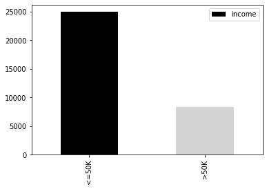

```python
#plot income <=50  and >50
df['income'].value_counts().plot(kind='bar', color=['black', 'lightgrey'], legend='best')
```

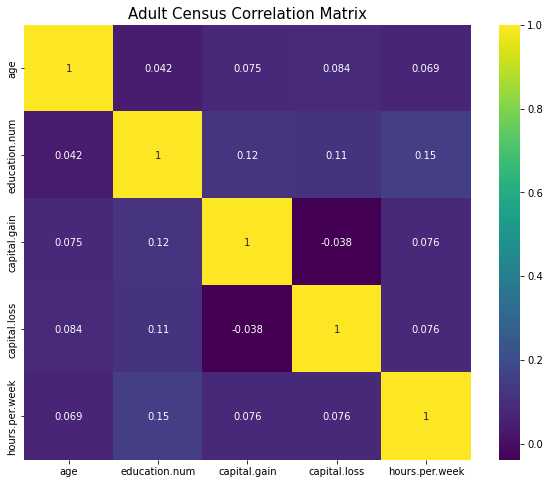

```python
# Plot a correlation matrix, before preprocessing and cleaning data, to see how features are related to each other
corr_matrix = df.corr()
fig, ax = plt.subplots(figsize=(10,8))
sns.heatmap(data=corr_matrix, annot=True, cmap='viridis')
ax.set_title('Adult Census Correlation Matrix', fontsize=15);
```

[output not shown]

[output cut: 19 more lines]

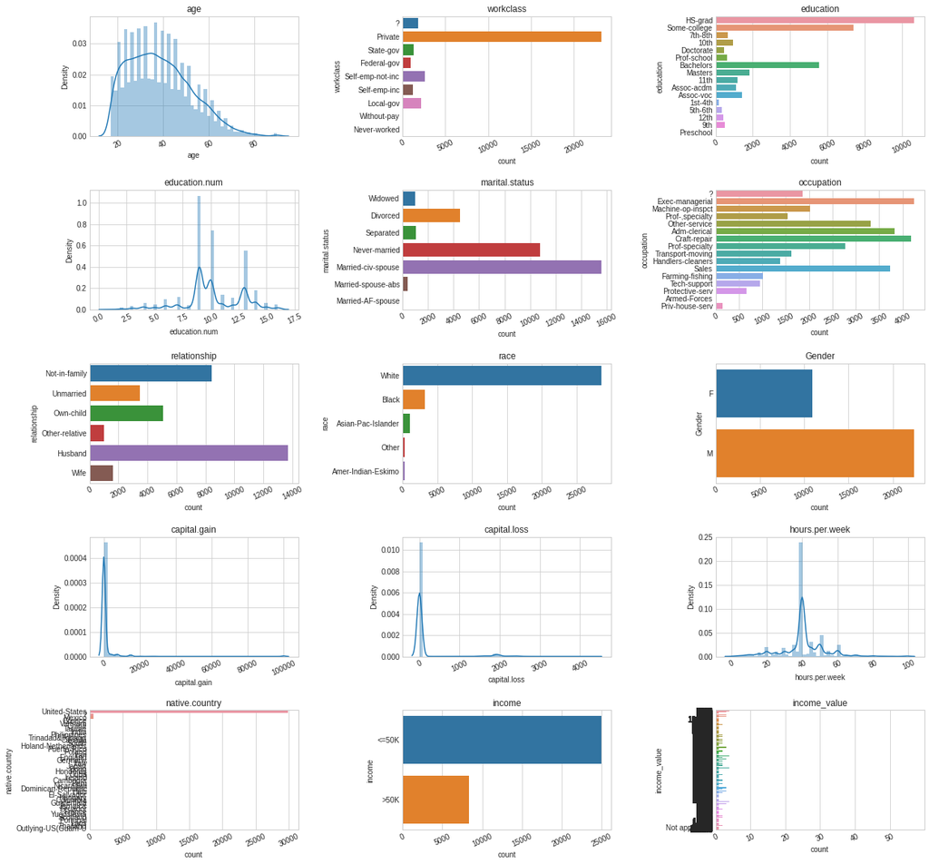

```python
# Let’s plot the distribution of each feature
def plot_distribution(dataset, cols=5, width=20, height=15, hspace=0.2, wspace=0.5):
    plt.style.use('seaborn-whitegrid')
    fig = plt.figure(figsize=(width,height))
    fig.subplots_adjust(left=None, bottom=None, right=None, top=None, wspace=wspace, hspace=hspace)
    rows = math.ceil(float(dataset.shape[1]) / cols)
    for i, column in enumerate(dataset.columns):
        ax = fig.add_subplot(rows, cols, i + 1)
        ax.set_title(column)
        if dataset.dtypes[column] == np.object:
            g = sns.countplot(y=column, data=dataset)
            substrings = [s.get_text()[:18] for s in g.get_yticklabels()]
            g.set(yticklabels=substrings)
            plt.xticks(rotation=25)
        else:
            g = sns.distplot(dataset[column])
            plt.xticks(rotation=25)

plot_distribution(df, cols=3, width=20, height=20, hspace=0.45, wspace=0.5)
```

### Native countries

- Check ripartition of Native Countries between people surveyed
- We notice that mayority of the citizens who took part in the census were born in the USA
- Also there are people from foreign countries also do this survey

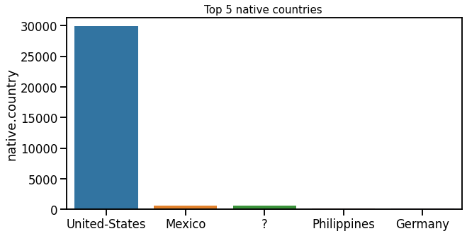

```python
sns.set_context('talk')
fig, ax = plt.subplots(figsize=(10, 5))
s = df['native.country'].value_counts()[:5]
ax = sns.barplot(x = s.index, y = s)
ax.set_title('Top 5 native countries ', fontsize=15);
```

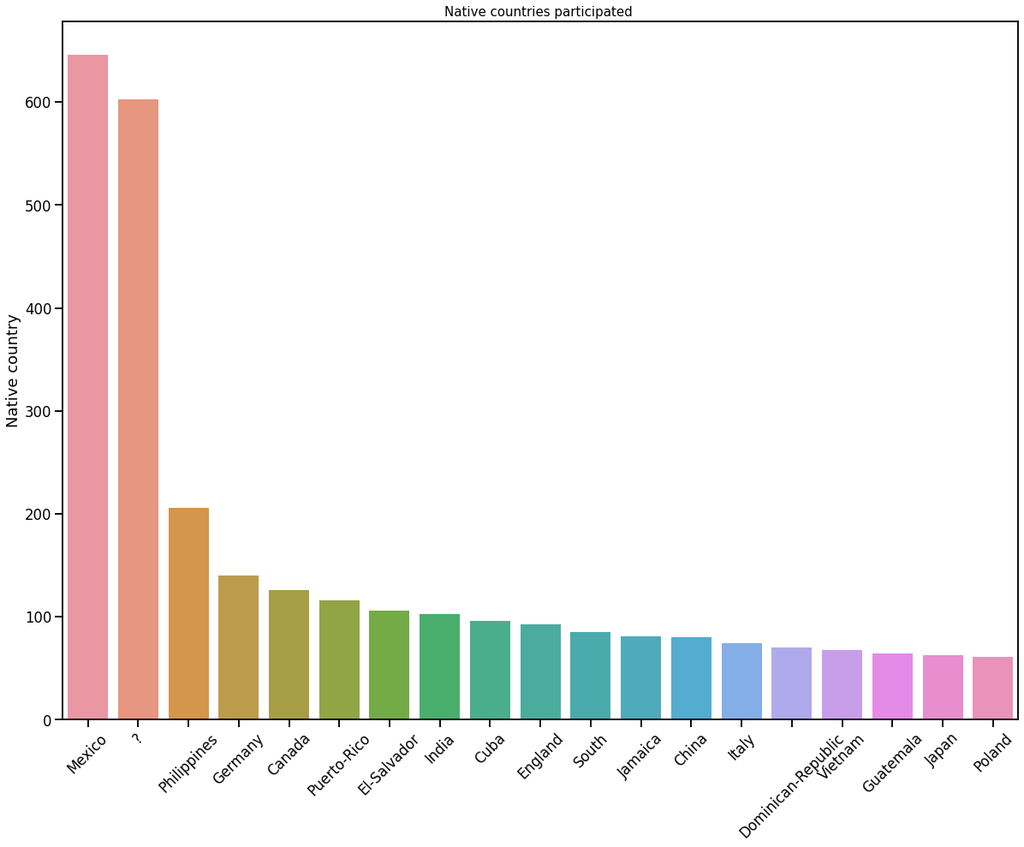

```python
sns.set_context('talk')
fig, ax = plt.subplots(figsize=(20, 15))
c = df['native.country'].value_counts()[1:20]
ax = sns.barplot(x = c.index, y = c)
ax.set_title('Native countries participated ', fontsize=15)
plt.xticks(rotation = 45)
plt.ylabel('Native country');
```

## Gender distribution

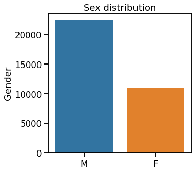

```python
fig, ax = plt.subplots(figsize=(5,5))
sex = df.Gender.value_counts()
ax = sns.barplot(x = sex.index, y = sex)
plt.title('Sex distribution');
```

### Occupation

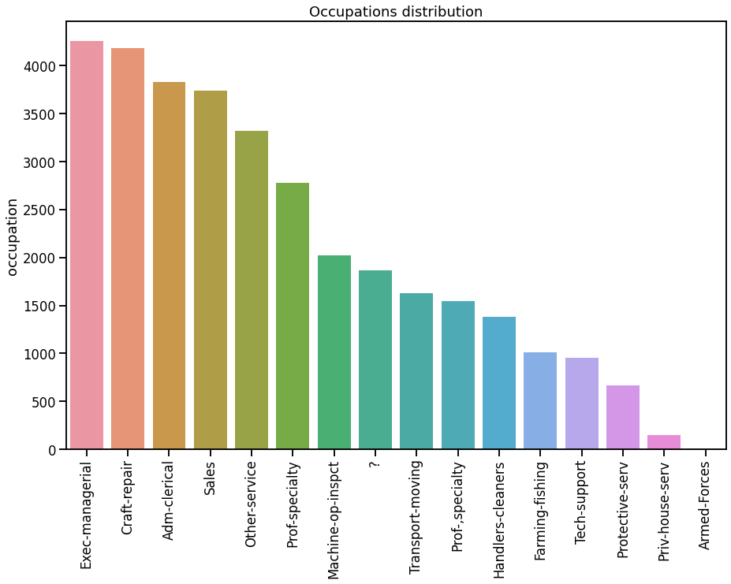

```python
fig, ax = plt.subplots(figsize=(15,10))
o = df.occupation.value_counts()
ax = sns.barplot(x = o.index, y=o)
plt.xticks(rotation=90)
plt.title('Occupations distribution');
```

## Relationship Status

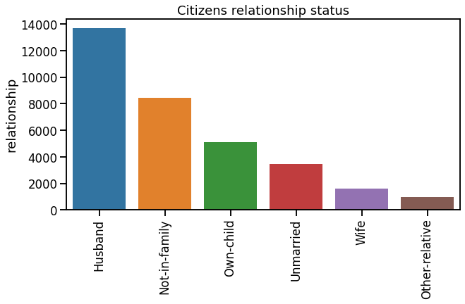

```python
sns.set_context('talk')
fig, ax = plt.subplots(figsize=(10,5))
o = df.relationship.value_counts()
ax = sns.barplot(x = o.index, y=o)
plt.xticks(rotation=90)
plt.title('Citizens relationship status');
```

### Age distribution

- Get an idea of the population's age,and the most of particcipant between 20 to 55 years old
- people who makes more than 50k their age between 40 to 50 years old

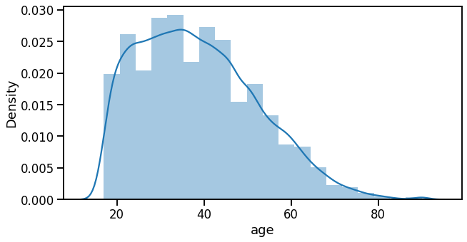

```python
fig, ax = plt.subplots(figsize=(10,5))
sns.distplot(df['age'],bins=20);
```

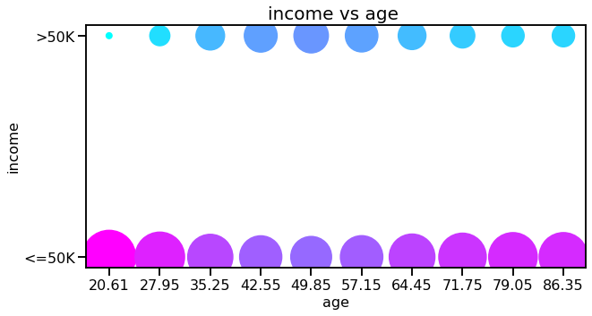

```python
bubble_plot(df,'age','income', normalization_by_all=False)
```

# Income based on Gender

- We can see that men are more likely to be both above 50K and below 50K. We can also see that women are more likely to have an income of less than 50K

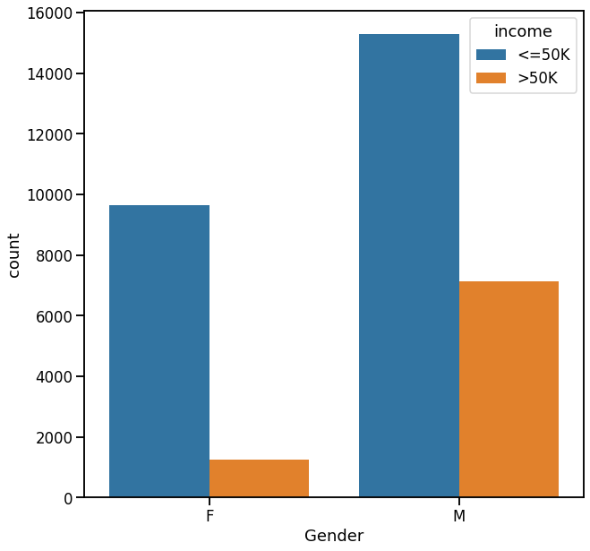

```python
fig, ax = plt.subplots(figsize=(10,10))
sns.countplot(df['Gender'],hue=df['income']);
```

# Income Based on Education

- This tells us that those that had less than a 12th grade education have a very slim chance of making more than 50K. It also tells us that an education of at least a high school diploma drastically increases your chances of making more than $50K. This also shows us that once we get to higher education levels past a bachelors, there are more people with incomes higher than 50K than those below.

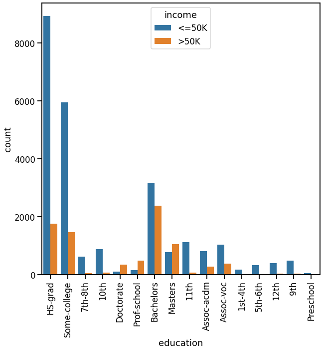

```python
fig, ax = plt.subplots(figsize=(10,10))
sns.countplot(df['education'],hue=df['income']);
plt.xticks(rotation=90)
```

### Income based on occupation

- This graph tells us that most people with high incomes had jobs in the Prof-speciality, Craft-repair, Exec-managerial, Adm-clerical, and Sales categories. Prof-speciality and Exec-managerial especially had a high amount of people with incomes above 50K. We can also see that those in the priv-house-serviceare gauranteed to not earn above 50K

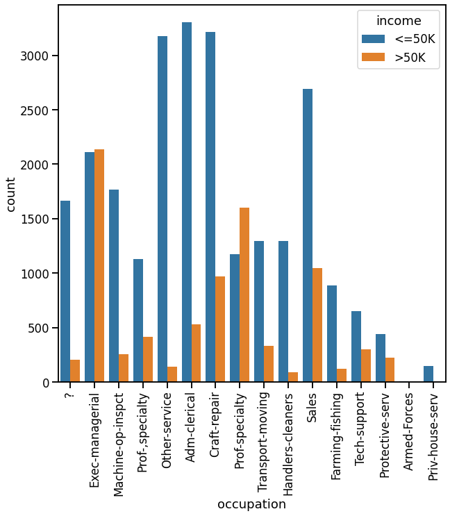

```python
fig, ax = plt.subplots(figsize=(10,10))
sns.countplot(df['occupation'],hue=df['income']);
plt.xticks(rotation=90)
```

# Income Based on Martial status

- we can observe that people have martial status Married-civ-spouse have higer income more than 50k
- and people where not married have income less than 50K

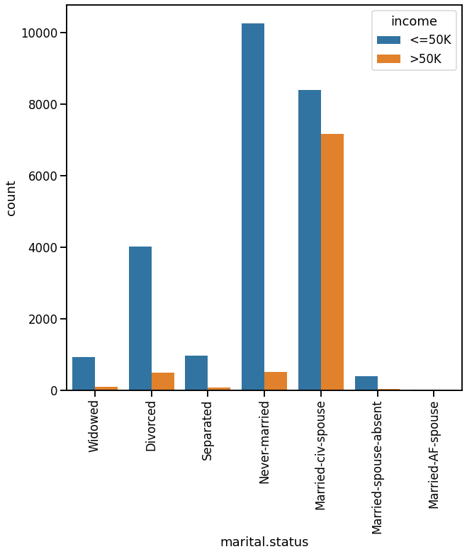

```python
fig, ax = plt.subplots(figsize=(10,10))

sns.countplot(df['marital.status'],hue=df['income']);
plt.xticks(rotation=90)
```

### Income based on Relationship

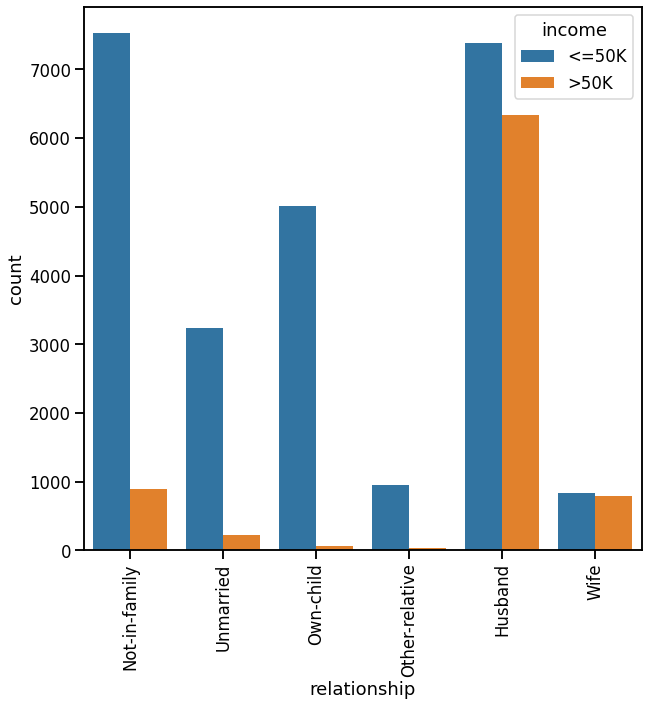

```python
fig, ax = plt.subplots(figsize=(10,10))

sns.countplot(df['relationship'],hue=df['income']);
plt.xticks(rotation=90)
```

### Income based on Working hours

- We can see that those that made more than 50K worked 40 or more hours per week. a very small amount of those with high incomes worked less than 40 hours per week.

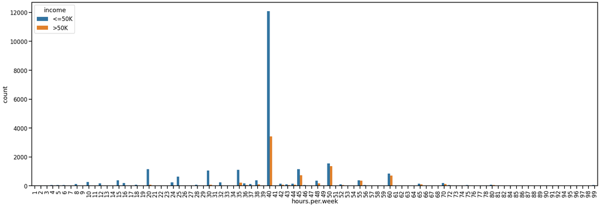

```python
fig, ax = plt.subplots(figsize=(30,10))

sns.countplot(df['hours.per.week'],hue=df['income']);
plt.xticks(rotation=90)
```

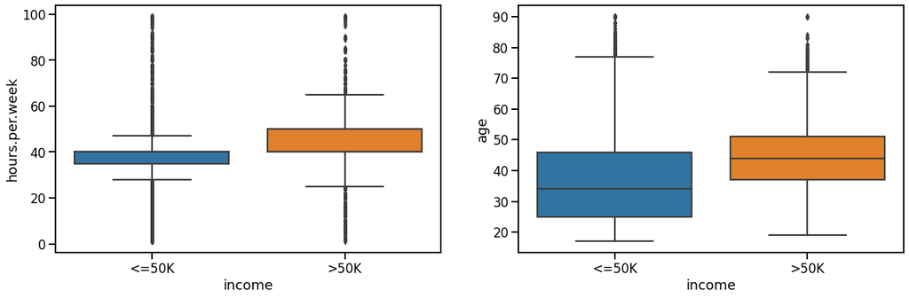

```python
fig, (a,b)= plt.subplots(1,2,figsize=(20,6))
sns.boxplot(y='hours.per.week',x='income',data=df,ax=a)
sns.boxplot(y='age',x='income',data=df,ax=b)
```

### Capital loss vs Education

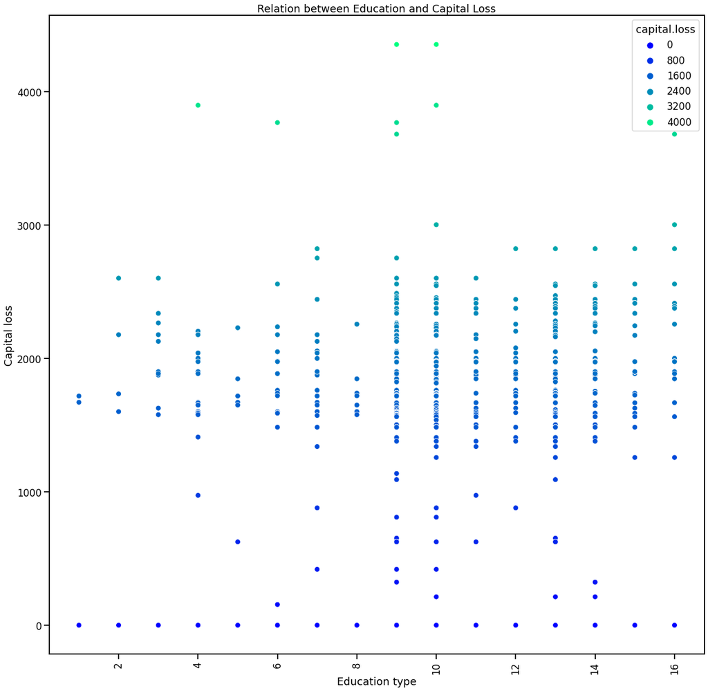

```python
fig, ax = plt.subplots(figsize=(20,20))
ax = sns.scatterplot(y=df['capital.loss'], x=df['education.num'], hue=df['capital.loss'], palette='winter')
plt.xticks(rotation=90)
plt.title('Relation between Education and Capital Loss')
plt.ylabel('Capital loss')
plt.xlabel('Education type');
```

# Data Cleaning

## Quality issue

- Drop column income_value

```python
# Drop income_value column because it has more than 20000 missing values
df.drop(['income_value'], axis=1,inplace=True)
```

```python
# Test
df.head()
```

| ID | age | workclass | education | education.num | marital.status | occupation | relationship | race | Gender | capital.gain | capital.loss | hours.per.week | native.country | income |
| --- | --- | --- | --- | --- | --- | --- | --- | --- | --- | --- | --- | --- | --- | --- |
| 1 | 90 | ? | HS-grad | 9 | Widowed | ? | Not-in-family | White | F | 0 | 4356 | 40 | United-States | <=50K |
| 2 | 82 | Private | HS-grad | 9 | Widowed | Exec-managerial | Not-in-family | White | F | 0 | 4356 | 18 | United-States | <=50K |
| 3 | 66 | ? | Some-college | 10 | Widowed | ? | Unmarried | Black | F | 0 | 4356 | 40 | United-States | <=50K |
| 4 | 54 | Private | 7th-8th | 4 | Divorced | Machine-op-inspct | Unmarried | White | F | 0 | 3900 | 40 | United-States | <=50K |
| 5 | 41 | Private | Some-college | 10 | Separated | Prof-,specialty | Own-child | White | F | 0 | 3900 | 40 | United-States | <=50K |

## Quality issue

- Drop rows having (?)
- second option we can impute them with specific category for ex: unknown
- I choose the option of drop because i have large dataset

```python
# Check the columns have this value (?)
df.apply(CM)
```

```
age                  0
workclass         1860
education            0
education.num        0
marital.status       0
occupation        1867
relationship         0
race                 0
Gender               0
capital.gain         0
capital.loss         0
hours.per.week       0
native.country     603
income               0
dtype: int64
```

```python
df = df[df['workclass'] != '?']
df = df[df['occupation'] != '?']
df = df[df['native.country'] != '?']
```

```python
# Test
df.apply(CM)
```

```
age               0
workclass         0
education         0
education.num     0
marital.status    0
occupation        0
relationship      0
race              0
Gender            0
capital.gain      0
capital.loss      0
hours.per.week    0
native.country    0
income            0
dtype: int64
```

```python
df.info()
```

```
<class 'pandas.core.frame.DataFrame'>
Int64Index: 30890 entries, 2 to 776
Data columns (total 14 columns):
 #   Column          Non-Null Count  Dtype
---  ------          --------------  -----
 0   age             30890 non-null  int64
 1   workclass       30890 non-null  object
 2   education       30890 non-null  object
 3   education.num   30890 non-null  int64
 4   marital.status  30890 non-null  object
 5   occupation      30890 non-null  object
 6   relationship    30890 non-null  object
 7   race            30890 non-null  object
 8   Gender          30890 non-null  object
 9   capital.gain    30890 non-null  int64
 10  capital.loss    30890 non-null  int64
 11  hours.per.week  30890 non-null  int64
 12  native.country  30890 non-null  object
 13  income          30890 non-null  object
dtypes: int64(5), object(9)
memory usage: 3.5+ MB
```

# Saving Cleaned Data

```python
# get copy of cleaned dataset
df_clean=df.copy()
```

```python
# Save cleaned dataset
df_clean.to_csv('Cleaned Data.csv')
```

# Feature Encoding

```python
df_clean.dtypes=='object'
```

```
age               False
workclass          True
education          True
education.num     False
marital.status     True
occupation         True
relationship       True
race               True
Gender             True
capital.gain      False
capital.loss      False
hours.per.week    False
native.country     True
income             True
dtype: bool
```

```python
#set(df_clean['Gender'].values)
```

```python
GenderKey={'F':0, 'M':1}
```

```python
df_clean['Gender'] = df_clean['Gender'].map(GenderKey).astype(int)
```

```python
#set(df_clean['workclass'].values)
```

```python
workclassKey={'Federal-gov':0,\
 'Local-gov':1,\
 'Private':2,\
 'Self-emp-inc':3,\
 'Self-emp-not-inc':4, 'State-gov':5,\
 'Without-pay':6}

df_clean['workclass'] = df_clean['workclass'].map(workclassKey).astype(int)
```

```python
#set(df_clean.education.values)
```

```python
eduKey={'10th':0,
 '11th':1,
 '12th':2,
 '1st-4th':3,
 '5th-6th':4,
 '7th-8th':5,
 '9th':6,
 'Assoc-acdm':7,
 'Assoc-voc':8,
 'Bachelors':9,
 'Doctorate':10,
 'HS-grad':11,
 'Masters':12,
 'Preschool':13,
 'Prof-school':14,
 'Some-college':15}

df_clean['education'] = df_clean['education'].map(eduKey).astype(int)
```

```python
# set(df_clean.occupation.values)
```

```python
occupation_key = {'Adm-clerical':0,
 'Armed-Forces':1,
 'Craft-repair':2,
 'Exec-managerial':3,
 'Farming-fishing':4,
 'Handlers-cleaners':5,
 'Machine-op-inspct':6,
 'Other-service':7,
 'Priv-house-serv':8,
 'Prof-,specialty':9,
 'Prof-specialty':10,
 'Protective-serv':11,
 'Sales':12,
 'Tech-support':13,
 'Transport-moving':14}

df_clean['occupation'] = df_clean['occupation'].map(occupation_key).astype(int)
```

```python
#set(df_clean['native.country'].values)
```

```python
origin_key = {
'Cambodia':0,
 'Canada':1,
 'China':2,
 'Columbia':3,
 'Cuba':4,
 'Dominican-Republic':5,
 'Ecuador':6,
 'El-Salvador':7,
 'England':8,
 'France':9,
 'Germany':10,
 'Greece':11,
 'Guatemala':12,
 'Haiti':13,
 'Holand-Netherlands':14,
 'Honduras':15,
 'Hong':16,
 'Hungary':17,
 'India':18,
 'Iran':19,
 'Ireland':20,
 'Italy':21,
 'Jamaica':22,
 'Japan':23,
 'Laos':24,
 'Mexico':25,
 'Nicaragua':26,
 'Outlying-US(Guam-USVI-etc)':27,
 'Peru':28,
 'Philippines':29,
 'Poland':30,
 'Portugal':31,
 'Puerto-Rico':32,
 'Scotland':33,
 'South':34,
 'Taiwan':35,
 'Thailand':36,
 'Trinadad&Tobago':37,
 'United-States':38,
 'Vietnam':39,
 'Yugoslavia':40}



df_clean['native.country'] = df_clean['native.country'].map(origin_key).astype(int)
```

```python
 # set(df_clean['marital.status'].values)
```

```python
martialKey={'Divorced':0,
 'Married-AF-spouse':1,
 'Married-civ-spouse':2,
 'Married-spouse-absent':3,
 'Never-married':4,
 'Separated':5,
 'Widowed':6}

df_clean['marital.status'] = df_clean['marital.status'].map(martialKey).astype(int)
```

```python
# set(df_clean.race.values)
```

```python
racekey={'Amer-Indian-Eskimo':0, 'Asian-Pac-Islander':1, 'Black':2, 'Other':3, 'White':4}
```

```python
df_clean['race'] = df_clean['race'].map(racekey).astype(int)
```

```python
# set(df_clean.relationship.values)
```

```python
relationKey={'Husband':0,
 'Not-in-family':1,
 'Other-relative':2,
 'Own-child':3,
 'Unmarried':4,
 'Wife':5}
df_clean['relationship'] =df_clean['relationship'].map(relationKey).astype(int)
```

```python
# set(df_clean.income.values)
```

```python
incomeKey={'<=50K':0, '>50K':1}
df_clean['income'] = df_clean['income'].map(incomeKey).astype(int)
```

```python
df_clean.info()
```

```
<class 'pandas.core.frame.DataFrame'>
Int64Index: 30890 entries, 2 to 776
Data columns (total 14 columns):
 #   Column          Non-Null Count  Dtype
---  ------          --------------  -----
 0   age             30890 non-null  int64
 1   workclass       30890 non-null  int64
 2   education       30890 non-null  int64
 3   education.num   30890 non-null  int64
 4   marital.status  30890 non-null  int64
 5   occupation      30890 non-null  int64
 6   relationship    30890 non-null  int64
 7   race            30890 non-null  int64
 8   Gender          30890 non-null  int64
 9   capital.gain    30890 non-null  int64
 10  capital.loss    30890 non-null  int64
 11  hours.per.week  30890 non-null  int64
 12  native.country  30890 non-null  int64
 13  income          30890 non-null  int64
dtypes: int64(14)
memory usage: 3.5 MB
```

```python
df_clean.head()
```

| ID | age | workclass | education | education.num | marital.status | occupation | relationship | race | Gender | capital.gain | capital.loss | hours.per.week | native.country | income |
| --- | --- | --- | --- | --- | --- | --- | --- | --- | --- | --- | --- | --- | --- | --- |
| 2 | 82 | 2 | 11 | 9 | 6 | 3 | 1 | 4 | 0 | 0 | 4356 | 18 | 38 | 0 |
| 4 | 54 | 2 | 5 | 4 | 0 | 6 | 4 | 4 | 0 | 0 | 3900 | 40 | 38 | 0 |
| 5 | 41 | 2 | 15 | 10 | 5 | 9 | 3 | 4 | 0 | 0 | 3900 | 40 | 38 | 0 |
| 6 | 34 | 2 | 11 | 9 | 0 | 7 | 4 | 4 | 0 | 0 | 3770 | 45 | 38 | 0 |
| 7 | 38 | 2 | 0 | 6 | 5 | 0 | 4 | 4 | 1 | 0 | 3770 | 40 | 38 | 0 |

```python
df_encoded =df_clean.copy()
```

```python
df_encoded.head()
```

| ID | age | workclass | education | education.num | marital.status | occupation | relationship | race | Gender | capital.gain | capital.loss | hours.per.week | native.country | income |
| --- | --- | --- | --- | --- | --- | --- | --- | --- | --- | --- | --- | --- | --- | --- |
| 2 | 82 | 2 | 11 | 9 | 6 | 3 | 1 | 4 | 0 | 0 | 4356 | 18 | 38 | 0 |
| 4 | 54 | 2 | 5 | 4 | 0 | 6 | 4 | 4 | 0 | 0 | 3900 | 40 | 38 | 0 |
| 5 | 41 | 2 | 15 | 10 | 5 | 9 | 3 | 4 | 0 | 0 | 3900 | 40 | 38 | 0 |
| 6 | 34 | 2 | 11 | 9 | 0 | 7 | 4 | 4 | 0 | 0 | 3770 | 45 | 38 | 0 |
| 7 | 38 | 2 | 0 | 6 | 5 | 0 | 4 | 4 | 1 | 0 | 3770 | 40 | 38 | 0 |

```python
df_encoded.to_csv('encodedData.csv')
```

# Build ML Model

```python
!pip install catboost
```

```
     |████████████████████████████████| 76.6 MB 1.2 MB/s
```

```python
# Models SKlearn
from sklearn.linear_model import LogisticRegression
from sklearn.neighbors import KNeighborsClassifier
from sklearn.ensemble import RandomForestClassifier
from xgboost import XGBClassifier
from catboost import CatBoostClassifier

# Model evaluation
from sklearn.model_selection import train_test_split, cross_val_score
from sklearn.model_selection import RandomizedSearchCV, GridSearchCV
from sklearn.metrics import confusion_matrix, classification_report
from sklearn.metrics import precision_score, recall_score, f1_score
from sklearn.metrics import plot_roc_curve
```

```python
X = df_encoded.drop('income', axis=1)
y =df_encoded['income']

X.shape, y.shape
```

```
((30890, 13), (30890,))
```

```python
X_train, X_test, y_train, y_test = train_test_split(X,y,test_size=0.2)

X_train.shape, X_test.shape, y_train.shape, y_test.shape
```

```
((24712, 13), (6178, 13), (24712,), (6178,))
```

```python
# Organize all models inside a dictionary

models = {'Logistic Regression': LogisticRegression(max_iter=300),
          'KNN': KNeighborsClassifier(),
          'Random Forest': RandomForestClassifier(),
          'Logistic Regression': LogisticRegression(),
          'XGBoost': XGBClassifier(),
           'CatBoost': CatBoostClassifier()}

#***************************************************************************

# Create a function which Fits and Scores all models
"""
    Fits and evaluates different learning models
    models: estimators dictionary
    X_train: training data without labels
    X_test: test data without labels
    y_train: train set labels
    y_test: test set labels
"""

np.random.seed(42)

model_scores = {}

for name, model in models.items():
  # Fit the model to the data
  model.fit(X_train, y_train);
  # Evaluate model and append the results to the empty dictionary
  model_scores[name] = model.score(X_test, y_test);
```

[output not shown]

[output cut: 946 more lines]

[output not shown]

```python
df_score=pd.DataFrame(models_Scores ,index=['Accuracy'])
df_score
```

|  | Logistic Regression | KNN | Random Forest | XGBoost | CatBoost |
| --- | --- | --- | --- | --- | --- |
| Accuracy | 0.800745 | 0.841211 | 0.850761 | 0.859987 | 0.879249 |

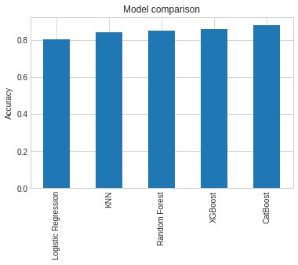

```python
df_score.T.plot(kind='bar',
                    title='Model comparison',
                    legend=False, )
plt.ylabel('Accuracy');
```

### Observation from fit_score and from bar chart is:

- the best performing models are
  - Random Forest
  - xgboost
  - catboost

## steps we are going to follow

- Hyperparameter tuning
- Evaluation Metrics
  - Recall
  - Confusion Matrix
  - Precision
  - F1 Score
  - ROC Curve and Area under the curve (AUC

-What most effective features

# Tuning Hyperparameters

## Xgboost

```python
# np.random.seed(42)
# xgb_para = {
#            'max_depth': np.arange(3,13,3),
#             'learning_rate': [0.1, 0.5, 0.3],
#             'gamma': [0, 0.1, 0.2],
#             'n_estimators': [1000, 1200],
#             }

# rs_xgb = RandomizedSearchCV(XGBClassifier(),
#                            param_distributions=xgb_para,
#                            n_jobs=-1)

# rs_xgb.fit(X_train, y_train)
```

```
RandomizedSearchCV(estimator=XGBClassifier(), n_jobs=-1,
                   param_distributions={'gamma': [0, 0.1, 0.2],
                                        'learning_rate': [0.1, 0.5, 0.3],
                                        'max_depth': array([ 3,  6,  9, 12]),
                                        'n_estimators': [1000, 1200]})
```

```python
# rs_xgb.best_params_
```

```
{'gamma': 0, 'learning_rate': 0.1, 'max_depth': 3, 'n_estimators': 1000}
```

```python
# rs_xgb.score(X_test, y_test)
```

```
0.8792489478795726
```

# Catboost

```python
cat_para = {'iterations': [200],
           'learning_rate': [ 0.04,0.3,0.4],
           'depth': np.arange(4, 8, 16),
           'grow_policy': ['Depthwise', 'Lossguide'],
            'max_leaves': [40, 60]
           }
```

```python
# Set a random seed
np.random.seed(42)

# Insatntiate the model
rs_cat = RandomizedSearchCV(CatBoostClassifier(),
                           param_distributions=cat_para,
                           cv=5,
                           verbose=True,
                           n_jobs=-1)
# Fit the RandomizedSearchCV
rs_cat.fit(X_train, y_train)
```

```
Fitting 5 folds for each of 8 candidates, totalling 40 fits
```

[output not shown]

[output cut: 145 more lines]

[output not shown]

[output not shown]

```python
rs_cat.best_params_
```

```
{'depth': 4,
 'grow_policy': 'Lossguide',
 'iterations': 200,
 'learning_rate': 0.3,
 'max_leaves': 40}
```

```python
rs_cat.score(X_train, y_train)
```

```
0.8965684687601165
```

### As we foundCatboost is the most performing model,So the next step is going through Evaluation Metrics

### Evaluation Merics

```python
y_preds = rs_cat.predict(X_test)
```

### ROC curve

- comparing the true positive rates to false positive

```
<sklearn.metrics._plot.roc_curve.RocCurveDisplay at 0x7f7c34170fd0>
```

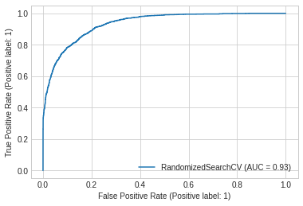

```python
# Plot ROC curve and calculate AUC metric
plot_roc_curve(rs_cat,X_test, y_test)
```

### Confusion Matrix

- Will give us a performance measurement for the machine learning classification problem

[figure not shown]

```python
fig, ax = plt.subplots(figsize=(3,3))
ax = sns.heatmap(confusion_matrix(y_test, y_preds), annot=True)
plt.xlabel('True labels')
plt.ylabel('Predicted labels')
plt.title('Confusion Matrix')
```

```python
print(classification_report(y_test, y_preds))
```

```
              precision    recall  f1-score   support

           0       0.90      0.94      0.92      4537
           1       0.81      0.70      0.75      1641

    accuracy                           0.88      6178
   macro avg       0.85      0.82      0.84      6178
weighted avg       0.87      0.88      0.87      6178
```